# Model 00: The Bivariate Series

**Helpers for column mapping, robust variance, and one bivariate fit**

```r
# Render a data frame as styled HTML for Quarto, or plainly for console use.
# Tall tables get a fixed-height scroll box so the report stays navigable.
print_table <- function(data, caption, align = NULL, scroll_height = NULL) {
  if (is.null(scroll_height) && nrow(data) > 25) scroll_height <- "600px"
  boxed <- data %>%
    knitr::kable(
      format = "html", caption = caption, escape = FALSE,
      align = align, row.names = FALSE
    ) %>%
    kableExtra::kable_styling(
      bootstrap_options = c("striped", "hover", "condensed"), full_width = FALSE
    )
  boxed <- if (is.null(scroll_height)) {
    kableExtra::scroll_box(boxed, width = "100%")
  } else {
    kableExtra::scroll_box(boxed, width = "100%", height = scroll_height)
  }
  cat(as.character(boxed))
  invisible(data)
}

to_yes_no <- function(x) {
  factor(ifelse(x %in% c(1, TRUE), "Yes", "No"), levels = c("No", "Yes"))
}

# Strip the variable-name prefix from a design column to recover the level
# label. Vectorised, because sub() uses only the first element of `pattern`.
strip_variable_prefix <- function(column, variable) {
  purrr::map2_chr(column, variable, ~ sub(paste0("^", .y), "", .x))
}

# Map each design column back to the variable and level that produced it, and
# record the position of that level so the display can preserve factor order.
column_map_for <- function(model_frame, term_vars) {
  model_formula <- stats::reformulate(term_vars)
  mm <- stats::model.matrix(model_formula, data = model_frame)
  assign_index <- attr(mm, "assign")
  term_labels <- attr(stats::terms(model_formula, data = model_frame), "term.labels")
  source_variable <- c("(Intercept)", term_labels)[assign_index + 1]
  keep <- colnames(mm) != "(Intercept)"

  tibble::tibble(
    column = colnames(mm)[keep],
    term_variable = source_variable[keep]
  ) %>%
    mutate(level = strip_variable_prefix(column, term_variable)) %>%
    group_by(term_variable) %>%
    mutate(level_index = dplyr::row_number()) %>%
    ungroup()
}

# Huber-White sandwich covariance for a weighted negative binomial fit, with
# theta held at its estimate. This is the weighting component of the design
# effect and nothing more: strata and PSUs are suppressed in the PUMF, so the
# clustering component is not recoverable. See decision 9.
robust_vcov <- function(nb_fit) {
  design <- stats::model.matrix(nb_fit)
  mu <- stats::fitted(nb_fit)
  y <- nb_fit$y
  w <- nb_fit$prior.weights
  score <- w * (y - mu) / (1 + mu / nb_fit$theta)
  bread <- stats::vcov(nb_fit)
  meat <- crossprod(design * score)
  bread %*% meat %*% bread
}

# Kish's approximate design effect from unequal weighting alone. The square root
# is the factor by which a design-based standard error would exceed the
# model-based one if weighting were the only departure from simple random
# sampling. It is a lower bound.
kish_design_effect <- function(w) {
  length(w) * sum(w^2) / (sum(w)^2)
}

# One model of the form outcome ~ cycle + predictor, plus the cycle-only null
# fitted on the SAME rows so the likelihood-ratio test is legitimate.
# Returns one row per estimated term, carrying the model-level diagnostics.
fit_bivariate <- function(base_frame, predictor, outcome, series_id) {
  needed <- c(outcome, weight_col, cycle_var, predictor)
  frame <- base_frame[, needed, drop = FALSE]
  frame <- frame[stats::complete.cases(frame), , drop = FALSE]
  # A level that vanished with the complete-case restriction would otherwise
  # contribute an all-zero design column and an unestimable coefficient.
  frame <- droplevels(frame)

  # Decision 11: rescale inside the estimation frame so sum(weights) == n_k.
  frame$weight_scaled <- frame[[weight_col]] / mean(frame[[weight_col]])
  n_used <- nrow(frame)

  full_formula <- stats::reformulate(c(cycle_var, predictor), response = outcome)
  null_formula <- stats::reformulate(cycle_var, response = outcome)
  environment(full_formula) <- environment()
  environment(null_formula) <- environment()

  attempt <- function(model_formula) {
    tryCatch(
      suppressWarnings(
        MASS::glm.nb(model_formula, data = frame, weights = weight_scaled,
                     control = stats::glm.control(maxit = 100))
      ),
      error = function(e) NULL
    )
  }

  full_fit <- attempt(full_formula)
  null_fit <- attempt(null_formula)

  if (is.null(full_fit)) {
    return(tibble::tibble(
      series_id = series_id, variable = predictor, column = NA_character_,
      level = NA_character_, level_index = NA_integer_, term_variable = NA_character_,
      estimate = NA_real_, std_error = NA_real_, robust_se = NA_real_,
      p_value = NA_real_, rate_ratio = NA_real_,
      ci_low = NA_real_, ci_high = NA_real_,
      ci_low_robust = NA_real_, ci_high_robust = NA_real_,
      n_used = n_used, theta = NA_real_, converged = FALSE, iterations = NA_integer_,
      aic = NA_real_, lr_statistic = NA_real_, lr_df = NA_integer_, lr_p = NA_real_,
      var_mean_ratio = NA_real_, reference_level = NA_character_,
      design_effect = NA_real_
    ))
  }

  map <- column_map_for(frame, c(cycle_var, predictor))
  robust_se <- sqrt(diag(robust_vcov(full_fit)))

  lr_statistic <- if (is.null(null_fit)) NA_real_ else {
    2 * (as.numeric(stats::logLik(full_fit)) - as.numeric(stats::logLik(null_fit)))
  }
  lr_df <- sum(map$term_variable == predictor)
  outcome_values <- frame[[outcome]]
  predictor_values <- frame[[predictor]]
  reference <- if (is.factor(predictor_values)) levels(predictor_values)[1] else "continuous"

  summary(full_fit)$coefficients %>%
    as.data.frame() %>%
    tibble::rownames_to_column("column") %>%
    rename(estimate = Estimate, std_error = `Std. Error`, p_value = `Pr(>|z|)`) %>%
    mutate(robust_se = robust_se[column]) %>%
    filter(column != "(Intercept)") %>%
    left_join(map, by = "column") %>%
    transmute(
      series_id = series_id,
      variable = predictor,
      column, level, level_index, term_variable,
      estimate, std_error, robust_se, p_value,
      rate_ratio = exp(estimate),
      ci_low  = exp(estimate - stats::qnorm(0.975) * std_error),
      ci_high = exp(estimate + stats::qnorm(0.975) * std_error),
      ci_low_robust  = exp(estimate - stats::qnorm(0.975) * robust_se),
      ci_high_robust = exp(estimate + stats::qnorm(0.975) * robust_se),
      n_used = n_used,
      theta = full_fit$theta,
      converged = full_fit$converged,
      iterations = full_fit$iter,
      aic = stats::AIC(full_fit),
      lr_statistic = lr_statistic,
      lr_df = lr_df,
      lr_p = stats::pchisq(lr_statistic, df = lr_df, lower.tail = FALSE),
      var_mean_ratio = stats::var(outcome_values) / mean(outcome_values),
      reference_level = reference,
      design_effect = kish_design_effect(frame[[weight_col]])
    )
}
```

# Data

**Load the Ellis respondent-level analytical parquet**

```r
ds0 <- arrow::read_parquet(path_parquet)
```

**Build the model frame and the shared-basis row filter**

```r
# One model frame serves all four series. Missingness is NOT resolved here:
# each fit resolves it against its own two columns (decision 5), and the shared
# basis is a row filter applied on top.
ds_model <- ds0 %>%
  select(all_of(c(outcome_primary, outcome_sensitivity, weight_col, cycle_var,
                  included_vars))) %>%
  mutate(across(where(is.ordered), ~ factor(., ordered = FALSE))) %>%
  mutate(across(where(is.logical), to_yes_no)) %>%
  mutate(across(all_of(c("dhhgle5", "dhhg611", "dhhgl12")), to_yes_no)) %>%
  mutate(across(where(is.character), factor)) %>%
  filter(!is.na(.data[[weight_col]]), !is.na(.data[[cycle_var]])) %>%
  mutate(.respondent_id = dplyr::row_number())

n_source <- nrow(ds0)
n_universe <- nrow(ds_model)

shared_flag <- stats::complete.cases(ds_model[, c(cycle_var, included_vars)])
ds_shared <- ds_model %>% filter(shared_flag)
n_shared <- nrow(ds_shared)

base_frames <- list(per_predictor = ds_model, shared = ds_shared)
```

```
Rows: 63,843
Columns: 70
$ cchs_cycle               <int> 0, 0, 0, 0, 0, 0, 0, 0, 0, 0, 0, 0, 0, 0, 0, 0, 0, 0, 0, 0, 0, 0,…
$ cchs_cycle_f             <fct> 2010-2011, 2010-2011, 2010-2011, 2010-2011, 2010-2011, 2010-2011,…
$ wts_m                    <dbl> 293.76, 743.82, 2984.93, 975.96, 387.17, 415.98, 178.10, 472.60, …
$ wts_m_pooled             <dbl> 146.880, 371.910, 1492.465, 487.980, 193.585, 207.990, 89.050, 23…
$ days_absent_total        <dbl> 0, 1, 0, 5, 0, 0, 0, 0, 0, 0, 0, 0, 2, 3, 0, 0, 0, 0, 0, 2, 0, 0,…
$ days_absent_chronic      <dbl> 0, 1, 0, 4, 0, 0, 0, 0, 0, 0, 0, 0, 0, 0, 0, 0, 0, 0, 0, 0, 0, 0,…
$ lopg040                  <dbl> 0, 1, 0, 4, 0, 0, 0, 0, 0, 0, 0, 0, 0, 0, 0, 0, 0, 0, 0, 0, 0, 0,…
$ lopg070                  <dbl> 0, 0, 0, 0, 0, 0, 0, 0, 0, 0, 0, 0, 0, 0, 0, 0, 0, 0, 0, 0, 0, 0,…
$ lopg082                  <dbl> 0, 0, 0, 1, 0, 0, 0, 0, 0, 0, 0, 0, 0, 0, 0, 0, 0, 0, 0, 2, 0, 0,…
$ lopg083                  <dbl> 0, 0, 0, 0, 0, 0, 0, 0, 0, 0, 0, 0, 0, 3, 0, 0, 0, 0, 0, 0, 0, 0,…
$ lopg084                  <dbl> 0, 0, 0, 0, 0, 0, 0, 0, 0, 0, 0, 0, 2, 0, 0, 0, 0, 0, 0, 0, 0, 0,…
$ lopg085                  <dbl> 0, 0, 0, 0, 0, 0, 0, 0, 0, 0, 0, 0, 0, 0, 0, 0, 0, 0, 0, 0, 0, 0,…
$ lopg086                  <dbl> 0, 0, 0, 0, 0, 0, 0, 0, 0, 0, 0, 0, 0, 0, 0, 0, 0, 0, 0, 0, 0, 0,…
```

[output cut: 57 more lines]

# Data Context

For complete data documentation, see the Data Primer. This section covers only what Model 00 touches.

## Tables and columns

```
Source table: ./data-private/derived/cchs-2-tables/cchs_analytic.parquet
```

```
  grain:      one row per respondent, two pooled CCHS cycles
```

```
  rows:       63,843
```

```
  columns:    70
```

```
Columns this report draws on:
```

```
  outcome (primary):     days_absent_total
```

```
  outcome (sensitivity): days_absent_chronic
```

```
  weight:                wts_m_pooled (master weight halved for pooling)
```

```
  in every model:        cchs_cycle_f
```

```
  predictors:            49 of 52 registered, one per model (see Table t1)
```

```
 cchs_cycle_f respondents share
    2010-2011       32621 51.1%
    2013-2014       31222 48.9%
```

## A single respondent

Every count in this report is a count of respondents, and that claim holds only if one row means one person. The representative row below shows exactly what a single model sees when it selects its two columns.

```
Grain proof
```

```
  rows in source:          63,843
```

```
  rows with weight + cycle:63,843
```

```
  rows in shared basis:    48,932
```

```
  duplicated ids:          0
```

```
One respondent, every column available to estimation:
```

```
           Domain                        Variable                         Value
 Outcome / design               days_absent_total                            14
 Outcome / design             days_absent_chronic                             6
 Outcome / design                    wts_m_pooled                       100.625
 Outcome / design                    cchs_cycle_f                     2013-2014
         Exposure                          Asthma                           Yes
         Exposure                    Fibromyalgia                            No
         Exposure                       Arthritis                           Yes
         Exposure                   Back problems                           Yes
         Exposure                    Hypertension                            No
         Exposure                        Migraine                            No
         Exposure                        Diabetes                            No
         Exposure                   Heart disease                            No
         Exposure                          Cancer                           Yes
         Exposure      Stomach / intestinal ulcer                            No
         Exposure                          Stroke                            No
         Exposure                  Bowel disorder                            No
         Exposure        Chronic fatigue syndrome                            No
         Exposure Multiple chemical sensitivities                            No
         Exposure                   Mood disorder                           Yes
         Exposure                Anxiety disorder                           Yes
     Predisposing                       Age group                         25-54
     Predisposing                             Sex                        Female
     Predisposing                  Marital status                       Married
     Predisposing                  Household size                     2 persons
     Predisposing     Child aged 0-5 in household                            No
     Predisposing    Child aged 6-11 in household                            No
     Predisposing     Child under 12 in household                            No
     Predisposing                       Education       Post-secondary graduate
     Predisposing              Immigration status Non-immigrant (Canadian-born)
     Predisposing                Visible minority                         White
     Predisposing                  Home ownership                         Owner
     Predisposing             Living arrangements           Couple, no children
     Facilitating                Household income             $20,000 - $39,999
     Facilitating                        Province                            ON
     Facilitating                 Employment type                 Self-employed
     Facilitating                   Work schedule                     Part-time
     Facilitating             Occupation category              Sales / Services
     Facilitating                  Smoking status                  Never smoked
     Facilitating                    BMI category                          <NA>
     Facilitating               Physical activity                        Active
     Facilitating             Alcohol consumption            Occasional drinker
     Facilitating      Fruit / vegetable servings               5 to 10 per day
     Facilitating                     Work stress          Not at all stressful
            Needs   Self-perceived general health                          Fair
            Needs    Self-perceived mental health                          Fair
            Needs            Health vs prior year                Somewhat worse
            Needs       Injured in past 12 months                           Yes
            Needs               Needs help: meals                            No
            Needs             Needs help: errands                            No
            Needs           Needs help: housework                            No
            Needs       Needs help: personal care                            No
            Needs      Needs help: moving indoors                            No
            Needs            Needs help: finances                            No
```

## Distributions

```
                        outcome     n mean (unweighted) mean (weighted) variance (weighted)
         All-cause absence days 63843             1.351           1.245              15.422
 Chronic-condition absence days 63843             0.414           0.366               6.430
 zeros (%) median p90 maximum variance / mean
    70.495      0   3      63          12.390
    94.320      0   0      31          17.576
```

```
Equidispersion would put variance / mean at 1. Neither outcome is close,
```

```
which is why Section 5.3 specifies a negative binomial rather than a Poisson.
```

```
Weighting, before any model is fitted:
```

```
  weight range:            3.02 to 13166.31
```

```
  coefficient of variation: 1.611
```

```
  Kish design effect:       3.595
```

```
  effective sample size:   17,759 of 63,843
```

**Reading the outcome and weight summaries**

Two numbers here govern the rest of the report.

The **variance-to-mean ratio** is what makes the negative binomial the right likelihood: a Poisson model assumes this ratio equals 1, and neither outcome is anywhere near that.

The **Kish design effect** is what makes the intervals wrong. It measures how much the unequal survey weights alone inflate sampling variance relative to a simple random sample. Its square root is a multiplier on every standard error in this report — a multiplier that has *not* been applied, because Section 5.3 asks for a bootstrap correction that subsumes it and these data cannot supply one. Step 2 works through the consequence.

# Analysis

## Step 1 — The Bivariate Protocol

Section 5.3 says “each potential predictor variable individually.” Two questions have to be answered before a single model can be fitted: which variables count as potential predictors, and — since the answer is a list, not a formula — what happens to the ones that Model 1 found unusable.

Table t1: Candidate registry, sourced from scripts/modeling/candidate-registry.R. 49 of 52 variables receive a bivariate model; the three exclusions are inherited from model-1 and restated as decisions 2 and 3.

| Domain | Variable | Label | Fitted here | Reason for exclusion |
| --- | --- | --- | --- | --- |
| Exposure | cc_anxiety | Anxiety disorder | yes |  |
| Exposure | cc_arthritis | Arthritis | yes |  |
| Exposure | cc_asthma | Asthma | yes |  |
| Exposure | cc_back_problems | Back problems | yes |  |
| Exposure | cc_bowel_disorder | Bowel disorder | yes |  |
| Exposure | cc_copd | COPD | NO | Asked only of respondents aged 35+; 100% missing below 35 |
| Exposure | cc_cancer | Cancer | yes |  |
| Exposure | cc_fatigue_syndrome | Chronic fatigue syndrome | yes |  |
| Exposure | cc_diabetes | Diabetes | yes |  |
| Exposure | cc_fibromyalgia | Fibromyalgia | yes |  |
| Exposure | cc_heart_disease | Heart disease | yes |  |
| Exposure | cc_hypertension | Hypertension | yes |  |
| Exposure | cc_migraine | Migraine | yes |  |
| Exposure | cc_mood_disorder | Mood disorder | yes |  |
| Exposure | cc_chem_sensitivity | Multiple chemical sensitivities | yes |  |
| Exposure | cc_ulcer | Stomach / intestinal ulcer | yes |  |
| Exposure | cc_stroke | Stroke | yes |  |
| Predisposing | dhhgage | Age (5-year group) | NO | Same construct as age_group_3; Section 2.2 specifies the 3-category recode |
| Predisposing | age_group_3 | Age group | yes |  |
| Predisposing | dhhgle5 | Child aged 0-5 in household | yes |  |
| Predisposing | dhhg611 | Child aged 6-11 in household | yes |  |
| Predisposing | dhhgl12 | Child under 12 in household | yes |  |
| Predisposing | education | Education | yes |  |
| Predisposing | home_ownership | Home ownership | yes |  |
| Predisposing | household_size | Household size | yes |  |
| Predisposing | immigration_status | Immigration status | yes |  |
| Predisposing | living_arrangements | Living arrangements | yes |  |
| Predisposing | marital_status | Marital status | yes |  |
| Predisposing | sex | Sex | yes |  |
| Predisposing | visible_minority | Visible minority | yes |  |
| Facilitating | alcohol_type | Alcohol consumption | yes |  |
| Facilitating | bmi_category | BMI category | yes |  |
| Facilitating | employment_type | Employment type | yes |  |
| Facilitating | fruit_veg_daily | Fruit / vegetable servings | yes |  |
| Facilitating | has_family_doctor | Has family doctor | NO | Optional content: 100% missing in 2010-2011 outside Ontario; aliases cycle x province |
| Facilitating | income_hh | Household income | yes |  |
| Facilitating | occupation_category | Occupation category | yes |  |
| Facilitating | physical_activity | Physical activity | yes |  |
| Facilitating | province | Province | yes |  |
| Facilitating | smoking_status | Smoking status | yes |  |
| Facilitating | work_schedule | Work schedule | yes |  |
| Facilitating | work_stress | Work stress | yes |  |
| Needs | health_vs_prior_year | Health vs prior year | yes |  |
| Needs | injured_past_12m | Injured in past 12 months | yes |  |
| Needs | adl_errands | Needs help: errands | yes |  |
| Needs | adl_finances | Needs help: finances | yes |  |
| Needs | adl_housework | Needs help: housework | yes |  |
| Needs | adl_meals | Needs help: meals | yes |  |
| Needs | adl_moving_indoors | Needs help: moving indoors | yes |  |
| Needs | adl_personal_care | Needs help: personal care | yes |  |
| Needs | health_perceived | Self-perceived general health | yes |  |
| Needs | mental_health_perceived | Self-perceived mental health | yes |  |

The registry is not declared in this report. It is sourced from `scripts/modeling/candidate-registry.R`, the same object Model 1 uses, so that the two reports cannot drift apart. Earlier exploratory work kept these lists in several places and they did drift; that is the mistake the registry exists to prevent.

Table t11: Model inventory by Andersen domain. Every model also carries the cycle indicator, so the survey-design row is estimated 49 times over.

| Domain | Models fitted | Rate ratios estimated | Largest factor |
| --- | --- | --- | --- |
| Exposure | 16 | 16 | 2 |
| Predisposing | 12 | 27 | 8 |
| Facilitating | 11 | 36 | 11 |
| Needs | 10 | 19 | 5 |
| Survey design | 0 | 1 | 2 |

```
Section 5.3, as written:
```

```
  'For each potential predictor variable individually, fit a weighted
```

```
   negative binomial regression model with only that predictor and the
```

```
   cycle indicator, using survey weights. Report unadjusted prevalence
```

```
   rate ratios (PRs) and 95% confidence intervals.'
```

```
  'Confidence intervals must be computed using bootstrap variance
```

```
   estimation (500 bootstrap weights provided by Statistics Canada),
```

```
   NOT using standard model-based SEs with simple random sampling
```

```
   assumptions. Failure to use bootstrap weights will yield artificially
```

```
   narrow CIs.'
```

```
Delivered here:
```

```
                         requirement                 status
             One model per predictor                    met
 Predictor plus cycle indicator only                    met
        Negative binomial likelihood                    met
              Survey weights applied                    met
     Unadjusted rate ratios reported                    met
   95% confidence intervals reported                    met
       Bootstrap variance estimation NOT MET - data blocked
                                          where
                            Table t4, 49 models
                                     decision 4
                                   MASS::glm.nb
 wts_m_pooled, rescaled to mean 1 (decision 11)
                                       Table t4
                             Table t4, Graph g1
            decision 8; quantified in Table t21
```

```
The 500 bootstrap replicate weights do not exist for these two cycles.
```

```
Statistics Canada began distributing them with the 2015 CCHS; the 2010-2011
```

```
and 2013-2014 Public Use Microdata Files carry the master weight only, and
```

```
stratum and cluster identifiers are suppressed. Section 5.3 anticipates the
```

```
consequence correctly: the intervals below ARE artificially narrow. Step 2
```

```
estimates by how much.
```

**Review point 1**

Three things to agree or disagree with.

1. **The exclusions carry over.** `cc_copd` and `has_family_doctor` are excluded here for the same reasons Model 1 excludes them, even though a bivariate model *could* estimate both. Doing so would define each on a different population from the other 46 (decision 2).
2. **`dhhgage` stays out.** Collinearity with `age_group_3` is a multivariable problem that does not arise in a one-predictor model, so the usual reason does not apply. It is still withheld — to preserve row-for-row correspondence with Model 1 and to avoid reporting the same signal twice (decision 3). This is the most arguable exclusion in the report.
3. **Nothing else enters the models.** No age or sex adjustment, because “unadjusted” is what Section 5.3 asks for (decision 4).

## Step 2 — The Interval Problem

This step exists because Section 5.3 raises the issue itself, in bold, with a warning symbol. It is the only requirement in the section that these data cannot satisfy, and the honest response is to measure the gap rather than to note it and move on.

| # | Decision | Alternatives considered | Chosen | Rationale | Reverse by editing |
| --- | --- | --- | --- | --- | --- |
| 1 | Candidate list | Re-declare locally; source the model-1 registry | Source `scripts/modeling/candidate-registry.R` | A third copy of the candidate list is exactly the drift that the registry was created to end. The file carries a stopifnot() guard on the 51 / 48 counts. | `scripts/modeling/candidate-registry.R` |
| 2 | Excluded candidates | Refit cc_copd and has_family_doctor bivariately; honour the model-1 exclusions | Honour the model-1 exclusions | Bivariately, cc_copd is estimable on the 35+ subsample and has_family_doctor on Ontario-2011 plus all of 2014. Both would then estimate a rate ratio on a differently-defined population than the other … | `candidate_registry` status in the sourced registry file |
| 3 | Age resolution | age_group_3; dhhgage; both | age_group_3 | Collinearity is a multivariable problem and does not arise in a one-predictor model, so dhhgage COULD be fitted here. It is still withheld: offering two encodings of age would break the row-for-row co… | `candidate_registry` status for dhhgage |
| 4 | Model form | Predictor alone; predictor + cycle; predictor + cycle + age + sex | Predictor + cycle | Section 5.3 specifies the cycle indicator and nothing else. Adding demographic adjusters would make the estimates partially adjusted and no longer the ‘unadjusted PRs’ the section names. | `fit_bivariate()` in declare-functions |
| 5 | Analytic basis | Per-predictor complete case; the shared model-1 sample; both | Both, with per-predictor as primary | Per-predictor complete case is the conventional Table 2 behaviour and preserves the largest sample for each estimate, but it makes n vary from row to row. The shared basis fixes the rows at model-1’s … | `series_registry` in declare-globals |
| 6 | Outcome scope | days_absent_total only; both outcomes | Both, with days_absent_total as primary | Section 5.3 names one outcome; Section 4.1 names days_absent_chronic as the sensitivity outcome. It is 94% zeros, so its estimates are reported with a convergence and dispersion flag rather than prese… | `series_registry` in declare-globals |
| 7 | Row granularity | One row per variable; one row per non-reference level; both | Both | Section 5.3 asks for rate ratios, which exist only at the level. A variable-level omnibus test is added because a multi-level factor has no single PR and would otherwise be un-rankable. | `t41` chunk |
| 8 | Variance estimation | 500 bootstrap replicate weights; Wald standard errors | Wald standard errors, reported beside a robust sandwich alternative | DATA-BLOCKED. Bootstrap replicate weights are absent from the 2010 and 2014 PUMF files; Statistics Canada began releasing them with the 2015 cycle, and strata and PSU identifiers are suppressed. This … | Not reversible without a Research Data Centre file |
| 9 | Width-inflation instrument | Naive respondent-level bootstrap; Huber-White sandwich; Kish design effect; do nothing | Kish design effect plus a per-model sandwich | Both are computable from the PUMF and both isolate the weighting component of the design effect. Neither can recover the clustering component, so both are LOWER bounds on the true interval width. A na… | `robust_vcov()` in declare-functions |
| 10 | Multiplicity | Unadjusted p-values; Benjamini-Hochberg; Bonferroni | Unadjusted, with Benjamini-Hochberg shown alongside | Section 5.3 is a screening step feeding Section 5.4, not a confirmatory analysis, so unadjusted p-values are the requested quantity. The BH column is provided because 47 simultaneous tests invite over… | `t41` chunk |
| 11 | Weight handling | Raw master weights; weights rescaled to mean 1 within each estimation frame | Rescaled to mean 1 | Raw CCHS weights sum to the population, which would make glm.nb behave as though the sample contained 25 million observations. Rescaling preserves the relative weighting and sets the nominal n to the … | `fit_bivariate()` in declare-functions |

**The requirement that cannot be met**

Section 5.3 states: *“Confidence intervals must be computed using bootstrap variance estimation (500 bootstrap weights provided by Statistics Canada), NOT using standard model-based SEs with simple random sampling assumptions. Failure to use bootstrap weights will yield artificially narrow CIs.”*

The 500 replicate weights were not provided, because they do not exist for these cycles. Statistics Canada began distributing bootstrap weights with the CCHS 2015 file. The 2010–2011 and 2013–2014 Public Use Microdata Files carry the master weight only, and the stratum and cluster identifiers that would permit a Taylor-series alternative are suppressed as a confidentiality measure.

Section 5.3’s prediction is therefore correct: **every interval in this report is artificially narrow.** What follows is an attempt to say by how much.

**Fit every model in all four series, or reload the cached fits**

```r
fits_path <- paste0(fits_folder, "bivariate-terms.rds")

if (force_refit || !fs::file_exists(fits_path)) {
  fit_start <- Sys.time()
  bivariate_terms <- purrr::pmap_dfr(
    series_registry %>% select(series_id, outcome, basis),
    function(series_id, outcome, basis) {
      purrr::map_dfr(
        included_vars,
        ~ fit_bivariate(base_frames[[basis]], .x, outcome, series_id)
      )
    }
  )
  fit_duration <- round(as.numeric(difftime(Sys.time(), fit_start, units = "mins")), 2)
  attr(bivariate_terms, "fit_duration_min") <- fit_duration
  saveRDS(bivariate_terms, fits_path)
} else {
  bivariate_terms <- readRDS(fits_path)
  fit_duration <- attr(bivariate_terms, "fit_duration_min")
}

bivariate_terms <- bivariate_terms %>%
  mutate(
    domain = factor(variable_domains[variable], levels = domain_levels),
    variable_label = variable_labels[variable],
    is_cycle = term_variable == cycle_var,
    term = ifelse(is.na(level) | level == "", variable_label,
                  paste0(variable_label, ": ", level))
  )

readr::write_csv(
  bivariate_terms %>% select(-domain) %>%
    mutate(domain = variable_domains[variable]),
  paste0(local_data, "bivariate-terms.csv")
)

model_diagnostics <- bivariate_terms %>%
  distinct(series_id, variable, variable_label, domain, n_used, theta, converged,
           iterations, aic, lr_statistic, lr_df, lr_p, var_mean_ratio,
           reference_level, design_effect)

readr::write_csv(model_diagnostics, paste0(local_data, "model-diagnostics.csv"))
```

Table t21: How much narrower the reported intervals are likely to be. Both instruments are LOWER bounds: strata and PSU identifiers are suppressed in the PUMF, so the clustering component of the design effect is not merely unestimated but unestimable.

| Instrument | Quantity | Value | Accounts for | Cannot account for |
| --- | --- | --- | --- | --- |
| Kish design effect | n * sum(w^2) / (sum(w))^2 over the full universe | 3.595 | unequal weighting | stratification, clustering |
| Kish effective n | n / design effect | 17,759 of 63,843 | unequal weighting | stratification, clustering |
| Implied SE multiplier | sqrt(design effect) | 1.896 | unequal weighting | stratification, clustering |
| Sandwich SE multiplier (median) | median of robust SE / Wald SE across all Series S1 terms | 1.771 | unequal weighting, model misspecification | stratification, clustering |
| Sandwich SE multiplier (range) | range of robust SE / Wald SE across all Series S1 terms | 0.671 to 4.233 | unequal weighting, model misspecification | stratification, clustering |

```
Reading Table t21
```

```
A Wald interval on the log scale has half-width 1.96 * SE. If the true
```

```
design-based SE exceeds the model-based one by a factor k, then every
```

```
interval below is too narrow by that same factor on the log scale.
```

```
  Kish lower bound, k =         1.90
```

```
  Sandwich median,  k =         1.77
```

```
A rate ratio reported as 1.30 (1.20-1.41) would, at k = 1.90, become roughly
```

```
  1.30 (1.12-1.51)
```

```
This is illustrative arithmetic, not a correction that has been applied.
```

```
Every interval in Table t4 and Graph g1 is the uncorrected Wald interval,
```

```
because that is the quantity a reader can check against the model output.
```

```
The robust interval is carried alongside it in both artifacts.
```

```
What neither instrument recovers:
```

```
  - CCHS uses a multistage stratified cluster design. Clustering inflates
```

```
    variance further, typically by more than weighting does.
```

```
  - The 500 replicate weights encode BOTH components. Nothing computable
```

```
    from a PUMF substitutes for them.
```

```
  - Therefore: treat every interval here as a lower bound on width, and
```

```
    treat p-values near 0.05 as undecided rather than as decided.
```

Two instruments are used, and both measure the same thing from different directions. **Kish’s design effect** derives an inflation factor from the spread of the weights alone. The **Huber–White sandwich** derives one empirically from each fitted model, and additionally absorbs some mean-variance misspecification.

The sandwich ratios are not uniformly above 1. A handful of low-prevalence binary conditions produce robust standard errors *smaller* than their model-based counterparts, which is what a sandwich does when the few respondents carrying the exposure happen to be lightly weighted. Those cases are not evidence that the intervals are wide enough; they are evidence that a per-model empirical estimator is unstable when a cell is thin. The median is the number to read.

Neither sees clustering. CCHS draws respondents through a multistage stratified cluster design, and in health surveys the clustering component of the design effect is routinely larger than the weighting component. The two numbers in Table t21 are therefore not estimates of the shortfall — they are **lower bounds** on it.

```
Fitting log
```

```
  estimation time:      2.8 minutes
```

```
  models attempted:     196
```

```
  models converged:     196
```

```
  models failed:        0
```

```
 series_id                 series_label                        outcome                       basis
        S1                      Primary         All-cause absence days Per-predictor complete case
        S2           Sample sensitivity         All-cause absence days       Shared model-1 sample
        S3          Outcome sensitivity Chronic-condition absence days Per-predictor complete case
        S4 Sample x outcome sensitivity Chronic-condition absence days       Shared model-1 sample
 models converged failed median n          n range median theta
     49        49      0   63,840 59,389 to 63,843       0.1517
     49        49      0   48,932 48,932 to 48,932       0.1591
     49        49      0   63,840 59,389 to 63,843       0.0179
     49        49      0   48,932 48,932 to 48,932       0.0185
```

```
All models converged.
```

**Review point 2**

Agree or disagree that reporting Wald intervals, clearly labelled and flanked by a robust alternative and a measured lower bound on their understatement, is preferable to the two alternatives: reporting no intervals at all, or silently reporting the Wald intervals as though they answered Section 5.3.

If you disagree, decision 8 is not reversible without Research Data Centre access to the master files. That is a procurement decision, not an analytic one.

## Step 3 — Two Analytic Bases

Section 5.3 does not say which rows each model may use, and the two defensible answers give different samples. Rather than pick one silently, both are estimated and the difference is shown.

Table t3: What the per-predictor basis buys. The shared basis holds all 49 models at 48,932 respondents; the per-predictor basis lets each model use every row on which its own predictor is observed.

| Domain | Variable | n (per-predictor) | n (shared) | Rows gained | Gain (%) |
| --- | --- | --- | --- | --- | --- |
| Exposure | Anxiety disorder | 63,843 | 48,932 | 14,911 | +30.5% |
| Exposure | Arthritis | 63,843 | 48,932 | 14,911 | +30.5% |
| Exposure | Asthma | 63,843 | 48,932 | 14,911 | +30.5% |
| Exposure | Back problems | 63,843 | 48,932 | 14,911 | +30.5% |
| Exposure | Bowel disorder | 63,843 | 48,932 | 14,911 | +30.5% |
| Exposure | Cancer | 63,843 | 48,932 | 14,911 | +30.5% |
| Exposure | Chronic fatigue syndrome | 63,843 | 48,932 | 14,911 | +30.5% |
| Exposure | Diabetes | 63,843 | 48,932 | 14,911 | +30.5% |
| Exposure | Fibromyalgia | 63,843 | 48,932 | 14,911 | +30.5% |
| Exposure | Heart disease | 63,843 | 48,932 | 14,911 | +30.5% |
| Exposure | Hypertension | 63,843 | 48,932 | 14,911 | +30.5% |
| Exposure | Migraine | 63,843 | 48,932 | 14,911 | +30.5% |
| Exposure | Mood disorder | 63,843 | 48,932 | 14,911 | +30.5% |
| Exposure | Multiple chemical sensitivities | 63,843 | 48,932 | 14,911 | +30.5% |
| Exposure | Stomach / intestinal ulcer | 63,843 | 48,932 | 14,911 | +30.5% |
| Exposure | Stroke | 63,843 | 48,932 | 14,911 | +30.5% |
| Predisposing | Age group | 63,843 | 48,932 | 14,911 | +30.5% |
| Predisposing | Child aged 0-5 in household | 63,843 | 48,932 | 14,911 | +30.5% |
| Predisposing | Child aged 6-11 in household | 63,843 | 48,932 | 14,911 | +30.5% |
| Predisposing | Child under 12 in household | 63,843 | 48,932 | 14,911 | +30.5% |
| Predisposing | Education | 63,241 | 48,932 | 14,309 | +29.2% |
| Predisposing | Home ownership | 63,677 | 48,932 | 14,745 | +30.1% |
| Predisposing | Household size | 63,821 | 48,932 | 14,889 | +30.4% |
| Predisposing | Immigration status | 63,475 | 48,932 | 14,543 | +29.7% |
| Predisposing | Living arrangements | 63,488 | 48,932 | 14,556 | +29.7% |
| Predisposing | Marital status | 63,718 | 48,932 | 14,786 | +30.2% |
| Predisposing | Sex | 63,843 | 48,932 | 14,911 | +30.5% |
| Predisposing | Visible minority | 63,364 | 48,932 | 14,432 | +29.5% |
| Facilitating | Alcohol consumption | 63,586 | 48,932 | 14,654 | +29.9% |
| Facilitating | BMI category | 59,401 | 48,932 | 10,469 | +21.4% |
| Facilitating | Employment type | 59,964 | 48,932 | 11,032 | +22.5% |
| Facilitating | Fruit / vegetable servings | 61,668 | 48,932 | 12,736 | +26.0% |
| Facilitating | Household income | 59,426 | 48,932 | 10,494 | +21.4% |
| Facilitating | Occupation category | 59,708 | 48,932 | 10,776 | +22.0% |
| Facilitating | Physical activity | 63,822 | 48,932 | 14,890 | +30.4% |
| Facilitating | Province | 63,843 | 48,932 | 14,911 | +30.5% |
| Facilitating | Smoking status | 63,740 | 48,932 | 14,808 | +30.3% |
| Facilitating | Work schedule | 59,389 | 48,932 | 10,457 | +21.4% |
| Facilitating | Work stress | 63,583 | 48,932 | 14,651 | +29.9% |
| Needs | Health vs prior year | 63,794 | 48,932 | 14,862 | +30.4% |
| Needs | Injured in past 12 months | 63,807 | 48,932 | 14,875 | +30.4% |
| Needs | Needs help: errands | 63,836 | 48,932 | 14,904 | +30.5% |
| Needs | Needs help: finances | 63,832 | 48,932 | 14,900 | +30.5% |
| Needs | Needs help: housework | 63,829 | 48,932 | 14,897 | +30.4% |
| Needs | Needs help: meals | 63,842 | 48,932 | 14,910 | +30.5% |
| Needs | Needs help: moving indoors | 63,840 | 48,932 | 14,908 | +30.5% |
| Needs | Needs help: personal care | 63,841 | 48,932 | 14,909 | +30.5% |
| Needs | Self-perceived general health | 63,803 | 48,932 | 14,871 | +30.4% |
| Needs | Self-perceived mental health | 63,770 | 48,932 | 14,838 | +30.3% |

Variables with no missingness of their own gain the most from the per-predictor basis: under the shared rule they would be penalised for the missingness of variables they have nothing to do with. That is the argument for making per-predictor primary. The argument against it is directly visible in the table: n is not constant down the column, so two rate ratios in Table t4 are not strictly estimates on the same population.

**Review point 3**

Agree or disagree with decision 5 — that the per-predictor basis is primary and the shared basis is reported as a sensitivity. Graph g3 and Table t42 show what the choice is worth before you decide.

## Step 4 — Table 2

The deliverable.

Table t4: Section 5.3 Table 2. Unadjusted prevalence rate ratios for All-cause absence days, each from a separate negative binomial model containing only that predictor and the cycle indicator. Wald intervals are the reported quantity; robust intervals are shown beside them because neither is the bootstrap interval Section 5.3 requires (decisions 8 and 9).

| Domain | Variable | Level | Reference | n | PR | 95% CI (Wald) | 95% CI (robust) | p |
| --- | --- | --- | --- | --- | --- | --- | --- | --- |
| Exposure | Anxiety disorder | Yes | No | 63,843 | 2.328 | 2.120 - 2.556 | 2.066 - 2.623 | <0.001 |
| Exposure | Arthritis | Yes | No | 63,843 | 1.891 | 1.765 - 2.025 | 1.674 - 2.135 | <0.001 |
| Exposure | Asthma | Yes | No | 63,843 | 1.606 | 1.486 - 1.735 | 1.402 - 1.840 | <0.001 |
| Exposure | Back problems | Yes | No | 63,843 | 1.988 | 1.882 - 2.101 | 1.803 - 2.193 | <0.001 |
| Exposure | Bowel disorder | Yes | No | 63,843 | 2.302 | 2.069 - 2.560 | 1.979 - 2.677 | <0.001 |
| Exposure | Cancer | Yes | No | 63,843 | 3.101 | 2.482 - 3.874 | 2.448 - 3.928 | <0.001 |
| Exposure | Chronic fatigue syndrome | Yes | No | 63,843 | 3.723 | 2.927 - 4.735 | 2.973 - 4.662 | <0.001 |
| Exposure | Diabetes | Yes | No | 63,843 | 1.413 | 1.269 - 1.572 | 1.182 - 1.688 | <0.001 |
| Exposure | Fibromyalgia | Yes | No | 63,843 | 2.159 | 1.755 - 2.655 | 1.672 - 2.786 | <0.001 |
| Exposure | Heart disease | Yes | No | 63,843 | 1.884 | 1.635 - 2.172 | 1.509 - 2.354 | <0.001 |
| Exposure | Hypertension | Yes | No | 63,843 | 1.371 | 1.284 - 1.463 | 1.202 - 1.563 | <0.001 |
| Exposure | Migraine | Yes | No | 63,843 | 1.989 | 1.858 - 2.129 | 1.753 - 2.257 | <0.001 |
| Exposure | Mood disorder | Yes | No | 63,843 | 2.874 | 2.637 - 3.132 | 2.556 - 3.231 | <0.001 |
| Exposure | Multiple chemical sensitivities | Yes | No | 63,843 | 2.035 | 1.763 - 2.349 | 1.693 - 2.446 | <0.001 |
| Exposure | Stomach / intestinal ulcer | Yes | No | 63,843 | 2.275 | 1.978 - 2.616 | 1.769 - 2.925 | <0.001 |
| Exposure | Stroke | Yes | No | 63,843 | 1.922 | 1.309 - 2.822 | 1.314 - 2.811 | <0.001 |
| Predisposing | Age group | 25-54 | 15-24 | 63,843 | 1.194 | 1.125 - 1.266 | 1.072 - 1.330 | <0.001 |
| Predisposing | Age group | 55-75 | 15-24 | 63,843 | 1.067 | 0.993 - 1.146 | 0.944 - 1.206 | 0.078 |
| Predisposing | Child aged 0-5 in household | Yes | No | 63,843 | 0.930 | 0.875 - 0.988 | 0.842 - 1.028 | 0.019 |
| Predisposing | Child aged 6-11 in household | Yes | No | 63,843 | 0.882 | 0.832 - 0.935 | 0.781 - 0.996 | <0.001 |
| Predisposing | Child under 12 in household | Yes | No | 63,843 | 0.920 | 0.876 - 0.966 | 0.835 - 1.013 | <0.001 |
| Predisposing | Education | Secondary graduate | Less than secondary | 63,241 | 0.996 | 0.914 - 1.084 | 0.853 - 1.162 | 0.919 |
| Predisposing | Education | Some post-secondary | Less than secondary | 63,241 | 0.970 | 0.872 - 1.079 | 0.811 - 1.159 | 0.571 |
| Predisposing | Education | Post-secondary graduate | Less than secondary | 63,241 | 0.950 | 0.882 - 1.023 | 0.834 - 1.082 | 0.173 |
| Predisposing | Home ownership | Renter | Owner | 63,677 | 1.246 | 1.187 - 1.308 | 1.120 - 1.387 | <0.001 |
| Predisposing | Household size | 2 persons | 1 person | 63,821 | 0.902 | 0.840 - 0.968 | 0.819 - 0.993 | 0.004 |
| Predisposing | Household size | 3 persons | 1 person | 63,821 | 0.820 | 0.760 - 0.885 | 0.723 - 0.930 | <0.001 |
| Predisposing | Household size | 4 persons | 1 person | 63,821 | 0.755 | 0.700 - 0.813 | 0.649 - 0.878 | <0.001 |
| Predisposing | Household size | 5 or more persons | 1 person | 63,821 | 0.726 | 0.668 - 0.789 | 0.610 - 0.866 | <0.001 |
| Predisposing | Immigration status | Long-term immigrant (10+ yrs in Canada) | Non-immigrant (Canadian-born) | 63,475 | 0.822 | 0.776 - 0.871 | 0.727 - 0.929 | <0.001 |

[output cut: 68 more lines]

Each row is one non-reference level of one predictor, from a model containing only that predictor and the cycle indicator. The Wald column is the reported quantity; the robust column sits beside it so that the width difference is visible in every row rather than only in the summary of Step 2.

Table t41: Variable-level omnibus tests against the cycle-only model on identical rows. Because the likelihood is weighted, these are pseudo-likelihood-ratio statistics and their reference distribution is approximate; read the ranking, not the exact p-value.

| Rank | Domain | Variable | n | LR chi-sq | df | p | p (BH) | Survives BH at 0.05 |
| --- | --- | --- | --- | --- | --- | --- | --- | --- |
| 1 | Needs | Self-perceived general health | 63,803 | 1809.8 | 4 | <0.001 | <0.001 | yes |
| 2 | Needs | Health vs prior year | 63,794 | 1430.1 | 4 | <0.001 | <0.001 | yes |
| 3 | Needs | Injured in past 12 months | 63,807 | 820.6 | 1 | <0.001 | <0.001 | yes |
| 4 | Needs | Self-perceived mental health | 63,770 | 809.0 | 4 | <0.001 | <0.001 | yes |
| 5 | Needs | Needs help: housework | 63,829 | 757.9 | 1 | <0.001 | <0.001 | yes |
| 6 | Exposure | Mood disorder | 63,843 | 749.6 | 1 | <0.001 | <0.001 | yes |
| 7 | Exposure | Back problems | 63,843 | 664.9 | 1 | <0.001 | <0.001 | yes |
| 8 | Needs | Needs help: errands | 63,836 | 604.0 | 1 | <0.001 | <0.001 | yes |
| 9 | Facilitating | Work stress | 63,583 | 470.2 | 4 | <0.001 | <0.001 | yes |
| 10 | Exposure | Migraine | 63,843 | 450.9 | 1 | <0.001 | <0.001 | yes |
| 11 | Exposure | Anxiety disorder | 63,843 | 388.5 | 1 | <0.001 | <0.001 | yes |
| 12 | Exposure | Arthritis | 63,843 | 376.0 | 1 | <0.001 | <0.001 | yes |
| 13 | Needs | Needs help: meals | 63,842 | 358.2 | 1 | <0.001 | <0.001 | yes |
| 14 | Exposure | Bowel disorder | 63,843 | 294.6 | 1 | <0.001 | <0.001 | yes |
| 15 | Predisposing | Sex | 63,843 | 242.3 | 1 | <0.001 | <0.001 | yes |
| 16 | Predisposing | Living arrangements | 63,488 | 204.3 | 7 | <0.001 | <0.001 | yes |
| 17 | Exposure | Chronic fatigue syndrome | 63,843 | 175.5 | 1 | <0.001 | <0.001 | yes |
| 18 | Exposure | Stomach / intestinal ulcer | 63,843 | 167.4 | 1 | <0.001 | <0.001 | yes |
| 19 | Exposure | Asthma | 63,843 | 159.0 | 1 | <0.001 | <0.001 | yes |
| 20 | Facilitating | BMI category | 59,401 | 167.3 | 3 | <0.001 | <0.001 | yes |
| 21 | Exposure | Cancer | 63,843 | 141.6 | 1 | <0.001 | <0.001 | yes |
| 22 | Needs | Needs help: moving indoors | 63,840 | 125.8 | 1 | <0.001 | <0.001 | yes |
| 23 | Exposure | Multiple chemical sensitivities | 63,843 | 114.9 | 1 | <0.001 | <0.001 | yes |
| 24 | Facilitating | Smoking status | 63,740 | 115.1 | 3 | <0.001 | <0.001 | yes |
| 25 | Needs | Needs help: personal care | 63,841 | 104.6 | 1 | <0.001 | <0.001 | yes |
| 26 | Exposure | Hypertension | 63,843 | 95.3 | 1 | <0.001 | <0.001 | yes |
| 27 | Exposure | Heart disease | 63,843 | 91.0 | 1 | <0.001 | <0.001 | yes |
| 28 | Needs | Needs help: finances | 63,832 | 86.7 | 1 | <0.001 | <0.001 | yes |
| 29 | Predisposing | Household size | 63,821 | 94.0 | 4 | <0.001 | <0.001 | yes |
| 30 | Predisposing | Home ownership | 63,677 | 81.1 | 1 | <0.001 | <0.001 | yes |
| 31 | Predisposing | Marital status | 63,718 | 86.4 | 3 | <0.001 | <0.001 | yes |
| 32 | Facilitating | Employment type | 59,964 | 70.8 | 1 | <0.001 | <0.001 | yes |
| 33 | Exposure | Fibromyalgia | 63,843 | 66.7 | 1 | <0.001 | <0.001 | yes |
| 34 | Facilitating | Physical activity | 63,822 | 69.4 | 2 | <0.001 | <0.001 | yes |
| 35 | Facilitating | Household income | 59,426 | 70.7 | 4 | <0.001 | <0.001 | yes |
| 36 | Predisposing | Immigration status | 63,475 | 63.2 | 2 | <0.001 | <0.001 | yes |
| 37 | Exposure | Diabetes | 63,843 | 43.7 | 1 | <0.001 | <0.001 | yes |
| 38 | Predisposing | Age group | 63,843 | 41.7 | 2 | <0.001 | <0.001 | yes |
| 39 | Predisposing | Visible minority | 63,364 | 35.4 | 1 | <0.001 | <0.001 | yes |
| 40 | Facilitating | Work schedule | 59,389 | 33.6 | 1 | <0.001 | <0.001 | yes |
| 41 | Facilitating | Alcohol consumption | 63,586 | 33.4 | 2 | <0.001 | <0.001 | yes |
| 42 | Facilitating | Province | 63,843 | 49.0 | 10 | <0.001 | <0.001 | yes |
| 43 | Predisposing | Child aged 6-11 in household | 63,843 | 17.6 | 1 | <0.001 | <0.001 | yes |
| 44 | Facilitating | Fruit / vegetable servings | 61,668 | 19.4 | 2 | <0.001 | <0.001 | yes |
| 45 | Exposure | Stroke | 63,843 | 13.5 | 1 | <0.001 | <0.001 | yes |
| 46 | Predisposing | Child under 12 in household | 63,843 | 11.1 | 1 | <0.001 | <0.001 | yes |
| 47 | Predisposing | Child aged 0-5 in household | 63,843 | 5.4 | 1 | 0.020 | 0.021 | yes |
| 48 | Facilitating | Occupation category | 59,708 | 10.6 | 4 | 0.032 | 0.033 | yes |
| 49 | Predisposing | Education | 63,241 | 3.9 | 3 | 0.269 | 0.269 | no |

A multi-level factor has no single rate ratio, so a table of level-wise PRs cannot be ranked. The likelihood-ratio test against the cycle-only model on identical rows gives each variable one number and makes the screening ordering explicit. Two cautions: the likelihood is weighted, so these are pseudo-likelihood statistics whose reference distribution is approximate; and the same understated variance that narrows the intervals also inflates these statistics. Read the ranking, not the p-value.

**Order the terms to match the domain bands of model-1 Graph g4**

```r
# Ordering is deliberate. Within each domain band, variables appear in the same
# sequence as model-1 Graph g4 - alphabetically by label, reading from the
# bottom of the band upward - so the two artifacts can be laid side by side.
forest_base <- table_two %>%
  filter(!is.na(rate_ratio)) %>%
  arrange(domain, variable_label, level_index) %>%
  mutate(
    term = factor(term, levels = unique(term)),
    significant = ifelse(p_value < 0.05, "p < 0.05", "not significant")
  )

pr_axis_limits <- c(
  max(0.2, min(forest_base$ci_low, na.rm = TRUE)),
  min(10, max(forest_base$ci_high, na.rm = TRUE))
)
```

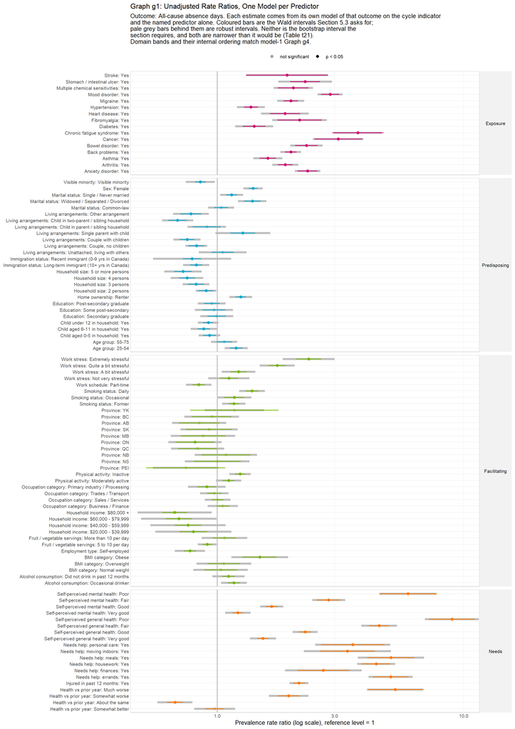

Graph g1 is the report’s central artifact, and it is drawn to be read next to Graph g4 of Model 1. The domain bands are the same, in the same order, and within each band the variables appear in the same sequence. Model 1’s g4 answers *did the penalty keep this variable?*; Model 00’s g1 answers *what did this variable look like on its own?* Laying them side by side shows which variables were dropped despite a visible unadjusted signal — the ones whose signal belonged to something else.

Three features of the graph are deliberate. Estimates whose $p \ge 0.05$ are drawn faded, so the eye is not drawn to noise. The pale grey bar behind each interval is the robust interval, so that the width penalty of Step 2 is visible at every row rather than stated once. And the x-axis is clipped: a few low-prevalence conditions produce intervals far wider than the panel, and letting them set the scale would flatten everything else into a line.

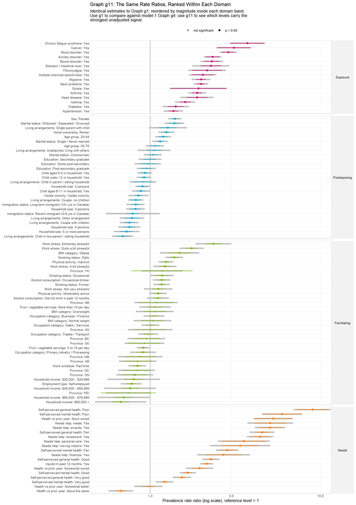

Graph g11 is g1 with the correspondence to Model 1 traded away for legibility. It is the graph to use when the question is “what is strongest,” and g1 is the graph to use when the question is “how does this compare with what the penalty kept.”

**Review point 4**

This is the report’s substantive output. Two questions to settle.

1. Is the level-wise presentation the right one, or should the report lead with the omnibus ranking in Table t41 and relegate levels to an appendix (decision 7)?
2. Should the ranking in Table t41 use unadjusted p-values, as it does, or the Benjamini–Hochberg column beside them (decision 10)? The unadjusted column is the screening quantity; the adjusted one guards against reading a table of 49 simultaneous tests as 49 independent findings.

## Step 5 — The Cycle Term

The cycle indicator appears in every model, so it is estimated once per predictor. That redundancy is free diagnostic information: if the two cycles were balanced on a predictor, adding that predictor could not move the cycle coefficient much.

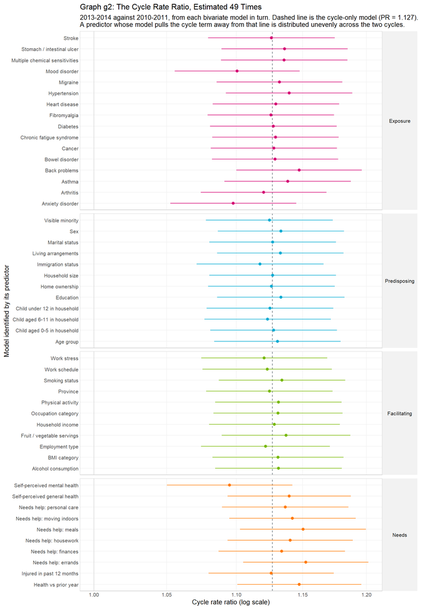

**Review point 5**

Agree or disagree that the cycle term is stable enough for the pooled design to stand. Large movement in this graph would not invalidate Table 2, but it would mean that “unadjusted, given cycle” is doing more work than the phrase suggests.

## Step 6 — Sensitivity

Series S1 rests on two choices Section 5.3 leaves open: which rows, and which outcome. Each is varied in turn.

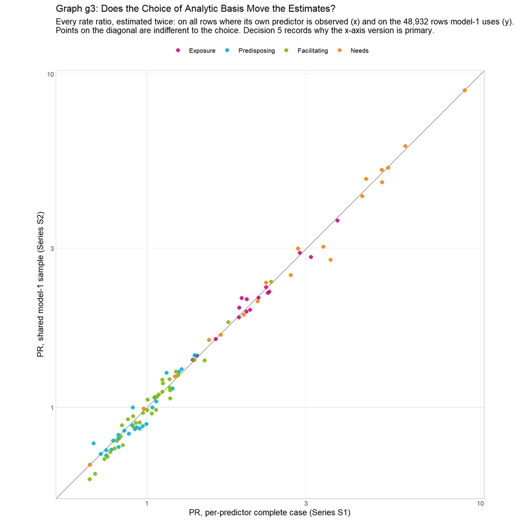

Points on the diagonal are indifferent to the choice of basis. Points off it identify estimates that depend on which rows were available, and those are precisely the estimates that should not be quoted from Table t4 without the qualification.

Table t42: The twenty estimates most sensitive to the choice of analytic basis. Anything listed as CROSSES 1 changes direction depending on which rows are used and should not be read from Table t4 alone.

| Domain | Term | PR (per-predictor) | PR (shared) | Ratio of PRs | Sign agreement |
| --- | --- | --- | --- | --- | --- |
| Needs | Needs help: personal care: Yes | 3.554 | 2.776 | 0.781 | same side of 1 |
| Predisposing | Living arrangements: Child in two-parent / sibling household | 0.691 | 0.781 | 1.131 | same side of 1 |
| Predisposing | Education: Secondary graduate | 0.996 | 0.892 | 0.896 | same side of 1 |
| Needs | Needs help: moving indoors: Yes | 3.377 | 3.037 | 0.899 | same side of 1 |
| Predisposing | Marital status: Single / Never married | 1.144 | 1.269 | 1.109 | same side of 1 |
| Exposure | Stroke: Yes | 1.922 | 2.127 | 1.107 | same side of 1 |
| Facilitating | Household income: $60,000 - $79,999 | 0.699 | 0.632 | 0.904 | same side of 1 |
| Facilitating | Province: YK | 1.174 | 1.064 | 0.906 | same side of 1 |
| Facilitating | Household income: $80,000 + | 0.672 | 0.609 | 0.906 | same side of 1 |
| Predisposing | Education: Some post-secondary | 0.970 | 0.879 | 0.906 | same side of 1 |
| Predisposing | Living arrangements: Child in parent / sibling household | 0.907 | 1.000 | 1.102 | same side of 1 |
| Predisposing | Education: Post-secondary graduate | 0.950 | 0.865 | 0.910 | same side of 1 |
| Exposure | Cancer: Yes | 3.101 | 2.825 | 0.911 | same side of 1 |
| Facilitating | Province: AB | 0.845 | 0.771 | 0.912 | same side of 1 |
| Facilitating | Alcohol consumption: Did not drink in past 12 months | 1.110 | 1.212 | 1.091 | same side of 1 |
| Facilitating | BMI category: Overweight | 1.064 | 0.983 | 0.924 | CROSSES 1 |
| Needs | Needs help: finances: Yes | 2.697 | 2.494 | 0.925 | same side of 1 |
| Predisposing | Immigration status: Long-term immigrant (10+ yrs in Canada) | 0.822 | 0.761 | 0.926 | same side of 1 |
| Facilitating | BMI category: Normal weight | 1.033 | 0.959 | 0.928 | CROSSES 1 |
| Facilitating | BMI category: Obese | 1.488 | 1.382 | 0.929 | same side of 1 |

Anything marked **CROSSES 1** changes direction depending on the basis. Those rows are not findings; they are artefacts of who happened to answer which questions.

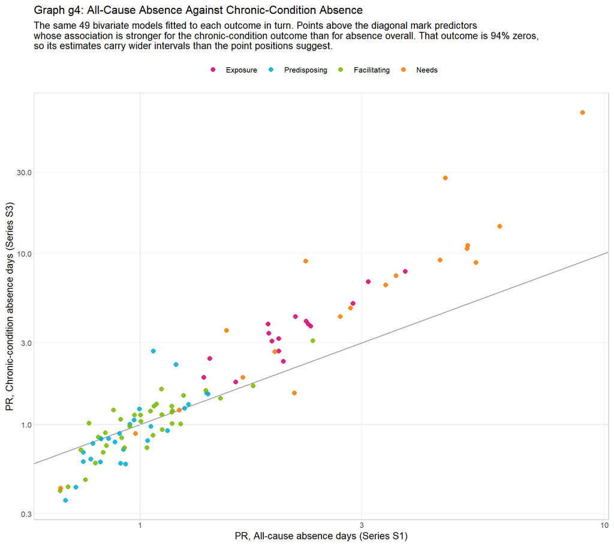

The chronic-condition outcome is a subset of the all-cause one and is overwhelmingly zero. Predictors above the diagonal associate more strongly with absence attributed to chronic conditions than with absence in general, which is the substantively interesting direction for this project — but the outcome’s sparsity means the vertical position of any single point is far less certain than its horizontal position.

Table t43: All four series side by side. Wald intervals throughout; see decision 8 for why none of them is the interval Section 5.3 requests.

| Domain | Term | S1 total / per-predictor | S2 total / shared | S3 chronic / per-predictor | S4 chronic / shared |
| --- | --- | --- | --- | --- | --- |
| Exposure | Anxiety disorder: Yes | 2.328 (2.120-2.556) | 2.224 (2.003-2.468) | 3.768 (2.887-4.916) | 3.505 (2.599-4.726) |
| Exposure | Arthritis: Yes | 1.891 (1.765-2.025) | 1.990 (1.846-2.146) | 3.421 (2.820-4.150) | 3.576 (2.890-4.425) |
| Exposure | Asthma: Yes | 1.606 (1.486-1.735) | 1.605 (1.471-1.752) | 1.775 (1.423-2.215) | 1.753 (1.364-2.252) |
| Exposure | Back problems: Yes | 1.988 (1.882-2.101) | 1.940 (1.825-2.061) | 3.181 (2.725-3.714) | 2.994 (2.519-3.557) |
| Exposure | Bowel disorder: Yes | 2.302 (2.069-2.560) | 2.205 (1.964-2.475) | 3.873 (2.861-5.243) | 3.627 (2.604-5.050) |
| Exposure | Cancer: Yes | 3.101 (2.482-3.874) | 2.825 (2.211-3.610) | 6.840 (3.618-12.931) | 5.920 (2.925-11.985) |
| Exposure | Chronic fatigue syndrome: Yes | 3.723 (2.927-4.735) | 3.637 (2.792-4.737) | 7.863 (3.944-15.677) | 7.997 (3.729-17.147) |
| Exposure | Diabetes: Yes | 1.413 (1.269-1.572) | 1.430 (1.270-1.611) | 2.436 (1.801-3.294) | 2.355 (1.680-3.301) |
| Exposure | Fibromyalgia: Yes | 2.159 (1.755-2.655) | 2.135 (1.711-2.665) | 4.291 (2.380-7.737) | 3.976 (2.106-7.507) |
| Exposure | Heart disease: Yes | 1.884 (1.635-2.172) | 1.862 (1.588-2.185) | 3.866 (2.585-5.784) | 3.748 (2.377-5.908) |
| Exposure | Hypertension: Yes | 1.371 (1.284-1.463) | 1.389 (1.293-1.494) | 1.886 (1.569-2.267) | 1.867 (1.521-2.293) |
| Exposure | Migraine: Yes | 1.989 (1.858-2.129) | 2.112 (1.958-2.278) | 2.695 (2.220-3.272) | 2.954 (2.378-3.670) |
| Exposure | Mood disorder: Yes | 2.874 (2.637-3.132) | 2.913 (2.648-3.204) | 5.118 (4.010-6.534) | 4.986 (3.796-6.548) |
| Exposure | Multiple chemical sensitivities: Yes | 2.035 (1.763-2.349) | 1.962 (1.674-2.300) | 2.346 (1.555-3.539) | 2.192 (1.388-3.463) |
| Exposure | Stomach / intestinal ulcer: Yes | 2.275 (1.978-2.616) | 2.297 (1.972-2.677) | 4.020 (2.698-5.988) | 3.777 (2.434-5.859) |
| Exposure | Stroke: Yes | 1.922 (1.309-2.822) | 2.127 (1.350-3.353) | 3.077 (1.028-9.207) | 3.453 (0.933-12.783) |
| Predisposing | Age group: 25-54 | 1.194 (1.125-1.266) | 1.140 (1.059-1.229) | 2.246 (1.899-2.657) | 1.974 (1.595-2.442) |
| Predisposing | Age group: 55-75 | 1.067 (0.993-1.146) | 1.043 (0.956-1.138) | 2.688 (2.196-3.292) | 2.415 (1.885-3.094) |
| Predisposing | Child aged 0-5 in household: Yes | 0.930 (0.875-0.988) | 0.872 (0.816-0.932) | 0.587 (0.494-0.697) | 0.549 (0.454-0.664) |
| Predisposing | Child aged 6-11 in household: Yes | 0.882 (0.832-0.935) | 0.834 (0.782-0.889) | 0.790 (0.671-0.931) | 0.741 (0.617-0.889) |
| Predisposing | Child under 12 in household: Yes | 0.920 (0.876-0.966) | 0.861 (0.815-0.909) | 0.714 (0.623-0.820) | 0.671 (0.576-0.782) |
| Predisposing | Education: Post-secondary graduate | 0.950 (0.882-1.023) | 0.865 (0.787-0.949) | 1.006 (0.816-1.239) | 0.792 (0.607-1.033) |
| Predisposing | Education: Secondary graduate | 0.996 (0.914-1.084) | 0.892 (0.803-0.991) | 1.232 (0.969-1.566) | 0.997 (0.740-1.344) |
| Predisposing | Education: Some post-secondary | 0.970 (0.872-1.079) | 0.879 (0.772-1.000) | 1.065 (0.789-1.439) | 0.785 (0.544-1.132) |
| Predisposing | Home ownership: Renter | 1.246 (1.187-1.308) | 1.279 (1.211-1.350) | 1.246 (1.085-1.429) | 1.263 (1.082-1.473) |
| Predisposing | Household size: 2 persons | 0.902 (0.840-0.968) | 0.885 (0.819-0.956) | 0.886 (0.725-1.081) | 0.882 (0.709-1.097) |
| Predisposing | Household size: 3 persons | 0.820 (0.760-0.885) | 0.828 (0.762-0.900) | 0.605 (0.489-0.750) | 0.629 (0.496-0.797) |
| Predisposing | Household size: 4 persons | 0.755 (0.700-0.813) | 0.743 (0.685-0.807) | 0.686 (0.556-0.846) | 0.734 (0.582-0.924) |
| Predisposing | Household size: 5 or more persons | 0.726 (0.668-0.789) | 0.725 (0.660-0.796) | 0.430 (0.340-0.543) | 0.427 (0.327-0.557) |
| Predisposing | Immigration status: Long-term immigrant (10+ yrs in Canada) | 0.822 (0.776-0.871) | 0.761 (0.713-0.812) | 0.828 (0.704-0.975) | 0.748 (0.624-0.898) |

[output cut: 68 more lines]

Table t5: Per-model diagnostics for Series S1. Theta far below 1 confirms severe overdispersion in every model, which is what makes the negative binomial likelihood the right choice and a Poisson the wrong one.

| Domain | Variable | Reference | n | Theta | Variance / mean | AIC | Iterations | Converged |
| --- | --- | --- | --- | --- | --- | --- | --- | --- |
| Exposure | Anxiety disorder | No | 63,843 | 0.1534 | 13.02 | 157,599 | 1 | yes |
| Exposure | Arthritis | No | 63,843 | 0.1533 | 13.02 | 157,611 | 1 | yes |
| Exposure | Asthma | No | 63,843 | 0.1518 | 13.02 | 157,828 | 1 | yes |
| Exposure | Back problems | No | 63,843 | 0.1553 | 13.02 | 157,322 | 1 | yes |
| Exposure | Bowel disorder | No | 63,843 | 0.1528 | 13.02 | 157,693 | 1 | yes |
| Exposure | Cancer | No | 63,843 | 0.1517 | 13.02 | 157,846 | 1 | yes |
| Exposure | Chronic fatigue syndrome | No | 63,843 | 0.1520 | 13.02 | 157,812 | 1 | yes |
| Exposure | Diabetes | No | 63,843 | 0.1510 | 13.02 | 157,944 | 1 | yes |
| Exposure | Fibromyalgia | No | 63,843 | 0.1512 | 13.02 | 157,920 | 1 | yes |
| Exposure | Heart disease | No | 63,843 | 0.1514 | 13.02 | 157,896 | 1 | yes |
| Exposure | Hypertension | No | 63,843 | 0.1514 | 13.02 | 157,892 | 1 | yes |
| Exposure | Migraine | No | 63,843 | 0.1538 | 13.02 | 157,536 | 1 | yes |
| Exposure | Mood disorder | No | 63,843 | 0.1560 | 13.02 | 157,238 | 1 | yes |
| Exposure | Multiple chemical sensitivities | No | 63,843 | 0.1515 | 13.02 | 157,872 | 1 | yes |
| Exposure | Stomach / intestinal ulcer | No | 63,843 | 0.1519 | 13.02 | 157,820 | 1 | yes |
| Exposure | Stroke | No | 63,843 | 0.1508 | 13.02 | 157,974 | 1 | yes |
| Predisposing | Age group | 15-24 | 63,843 | 0.1510 | 13.02 | 157,948 | 1 | yes |
| Predisposing | Child aged 0-5 in household | No | 63,843 | 0.1508 | 13.02 | 157,982 | 1 | yes |
| Predisposing | Child aged 6-11 in household | No | 63,843 | 0.1509 | 13.02 | 157,970 | 1 | yes |
| Predisposing | Child under 12 in household | No | 63,843 | 0.1508 | 13.02 | 157,976 | 1 | yes |
| Predisposing | Education | Less than secondary | 63,241 | 0.1508 | 13.01 | 156,592 | 1 | yes |
| Predisposing | Home ownership | Owner | 63,677 | 0.1513 | 13.02 | 157,566 | 1 | yes |
| Predisposing | Household size | 1 person | 63,821 | 0.1514 | 13.01 | 157,828 | 1 | yes |
| Predisposing | Immigration status | Non-immigrant (Canadian-born) | 63,475 | 0.1514 | 13.01 | 157,198 | 1 | yes |
| Predisposing | Living arrangements | Unattached, living alone | 63,488 | 0.1525 | 13.03 | 157,106 | 1 | yes |
| Predisposing | Marital status | Married | 63,718 | 0.1512 | 13.01 | 157,594 | 1 | yes |
| Predisposing | Sex | Male | 63,843 | 0.1524 | 13.02 | 157,745 | 1 | yes |
| Predisposing | Visible minority | White | 63,364 | 0.1513 | 13.01 | 156,774 | 1 | yes |
| Facilitating | Alcohol consumption | Regular drinker | 63,586 | 0.1513 | 13.01 | 157,426 | 1 | yes |
| Facilitating | BMI category | Underweight | 59,401 | 0.1517 | 13.23 | 146,814 | 1 | yes |
| Facilitating | Employment type | Employee | 59,964 | 0.1554 | 12.91 | 150,194 | 1 | yes |
| Facilitating | Fruit / vegetable servings | Less than 5 per day | 61,668 | 0.1512 | 13.05 | 152,897 | 1 | yes |
| Facilitating | Household income | No income or < $20,000 | 59,426 | 0.1539 | 12.98 | 148,351 | 1 | yes |
| Facilitating | Occupation category | Management / Education / Arts | 59,708 | 0.1552 | 12.93 | 149,818 | 1 | yes |
| Facilitating | Physical activity | Active | 63,822 | 0.1513 | 13.01 | 157,870 | 1 | yes |
| Facilitating | Province | NL | 63,843 | 0.1511 | 13.02 | 157,956 | 1 | yes |
| Facilitating | Smoking status | Never smoked | 63,740 | 0.1515 | 13.02 | 157,590 | 1 | yes |
| Facilitating | Work schedule | Full-time | 59,389 | 0.1560 | 12.89 | 149,079 | 1 | yes |
| Facilitating | Work stress | Not at all stressful | 63,583 | 0.1542 | 13.01 | 157,045 | 1 | yes |
| Needs | Health vs prior year | Much better | 63,794 | 0.1609 | 13.01 | 156,459 | 1 | yes |
| Needs | Injured in past 12 months | No | 63,807 | 0.1565 | 13.00 | 157,052 | 1 | yes |
| Needs | Needs help: errands | No | 63,836 | 0.1550 | 13.01 | 157,323 | 1 | yes |
| Needs | Needs help: finances | No | 63,832 | 0.1514 | 13.02 | 157,884 | 1 | yes |
| Needs | Needs help: housework | No | 63,829 | 0.1561 | 13.01 | 157,141 | 1 | yes |
| Needs | Needs help: meals | No | 63,842 | 0.1532 | 13.02 | 157,627 | 1 | yes |
| Needs | Needs help: moving indoors | No | 63,840 | 0.1516 | 13.02 | 157,854 | 1 | yes |
| Needs | Needs help: personal care | No | 63,841 | 0.1515 | 13.02 | 157,874 | 1 | yes |
| Needs | Self-perceived general health | Excellent | 63,803 | 0.1636 | 13.01 | 156,083 | 1 | yes |
| Needs | Self-perceived mental health | Excellent | 63,770 | 0.1563 | 13.02 | 157,019 | 1 | yes |

Theta far below 1 in every model confirms that the overdispersion seen in the Data Context section is not an artifact of the marginal distribution: it survives conditioning on each predictor in turn. That is the empirical justification for Section 5.3’s choice of a negative binomial rather than a Poisson, and for Section 5.4’s two-stage design.

**Review point 6**

Agree or disagree that the estimates in Table t4 are robust to the two choices varied here. If a predictor you care about appears in Table t42, or sits far off the diagonal in Graph g3 or g4, that predictor’s screening result should be treated as provisional.

## Step 7 — Reproducibility Ledger

Table t6: Artifact manifest. Every persisted object, with the call that reloads it.

| Artifact | Kind | Size | Reload with |
| --- | --- | --- | --- |
| data-local/bivariate-terms.csv | derived table | 257.45K | readr::read_csv(‘data-local/bivariate-terms.csv’) |
| data-local/decision-registry.csv | derived table | 4.33K | readr::read_csv(‘data-local/decision-registry.csv’) |
| data-local/model-diagnostics.csv | derived table | 35.34K | readr::read_csv(‘data-local/model-diagnostics.csv’) |
| data-local/omnibus-tests.csv | derived table | 10.02K | readr::read_csv(‘data-local/omnibus-tests.csv’) |
| data-local/sensitivity-wide.csv | derived table | 11.66K | readr::read_csv(‘data-local/sensitivity-wide.csv’) |
| data-local/table-two.csv | derived table | 43.67K | readr::read_csv(‘data-local/table-two.csv’) |
| data-local/fits/bivariate-terms.rds | fitted object | 52.67K | readRDS(‘data-local/fits/bivariate-terms.rds’) |

```
Reproducibility parameters
```

```
  outcome (primary):     days_absent_total
```

```
  outcome (sensitivity): days_absent_chronic
```

```
  weight:                wts_m_pooled (rescaled to mean 1 per estimation frame)
```

```
  in every model:        cchs_cycle_f
```

```
  candidate registry:    ./scripts/modeling/candidate-registry.R
```

```
  source parquet:        ./data-private/derived/cchs-2-tables/cchs_analytic.parquet
```

```
  models fitted:         196 (plus one null each)
```

```
  seed:                  42 (used only to draw the example respondent)
```

```
  cached fits:           ./analysis/model-00/data-local/fits/bivariate-terms.rds
```

```
  force_refit:           FALSE
```

```
Section 5.3 requirements NOT met by model-00:
```

```
  - Bootstrap variance estimation (decision 8: replicate weights absent from PUMF).
```

```
    This is the one requirement Section 5.3 flags explicitly, and it is the one
```

```
    requirement these data cannot satisfy. Table t21 measures the shortfall that
```

```
    is measurable; the clustering component is not.
```

```
  - Design-based degrees of freedom for the omnibus tests in Table t41.
```

# What Model 00 Settles, and What It Does Not

**Settled.**

- Every eligible candidate has an unadjusted rate ratio, estimated exactly as Section 5.3 specifies: its own model, its own predictor, the cycle indicator, survey weights, negative binomial likelihood.
- The candidate list is sourced, not re-typed, so Model 00 and Model 1 cannot disagree about what a candidate is.
- The two choices Section 5.3 leaves open — analytic basis and outcome — are both varied, and the estimates that depend on them are named.
- The interval shortfall is measured rather than asserted, with the measurable and unmeasurable components separated.

**Not settled.**

- *Variance estimation.* Decision 8 is data-blocked. Every interval is a Wald interval, understated by at least the factor in Table t21 and probably by more. Delivering Section 5.3 as written requires the CCHS master files.
- *Design-based inference generally.* The omnibus tests in Table t41 use nominal degrees of freedom. A design-based analysis would use degrees of freedom derived from the number of primary sampling units, which the PUMF suppresses.
- *`cc_copd` and `has_family_doctor`.* Both remain estimable on restricted populations and both remain unestimated. If either is wanted, it needs its own short report with its own sample definition, not a row in Table t4.
- *Section 5.1.* Missingness is handled by complete-case deletion within each model. Little’s MCAR test and multiple imputation are out of scope here.

**Recommended next step.** Read Graph g1 against Model 1’s Graph g4. The interesting cases are the disagreements: variables with a clear unadjusted signal that the penalty discarded, and variables the penalty kept that show little on their own. Both patterns are informative, and neither is visible from either report alone.

# Session Information

```
Rendered at:      2026-08-01 07:41:11
```

```
Render duration:  6.7 seconds
```